# Point Patterns II

HES 505 Fall 2025: Session 16

Matt Williamson

## Point Processes and Why You Should Care

- They’re ubiquitous
- Well-specified to many social and ecological theories
- Helps build intuition for interpolation

## The Poisson Distribution

- Discrete probability distribution
- Probability of events in a fixed interval of time or space
- Mean (expectation) = variance = $\lambda$

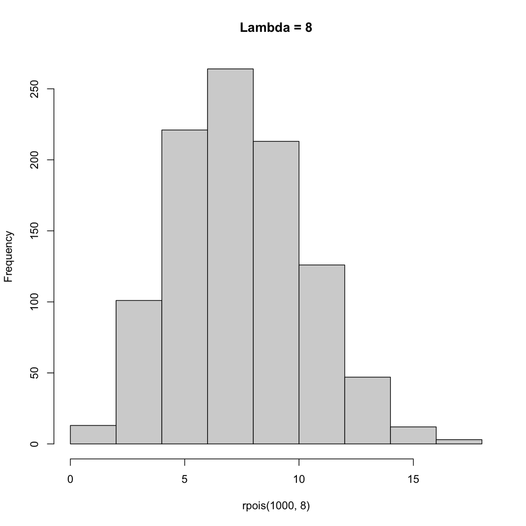

## Re-visiting CSR

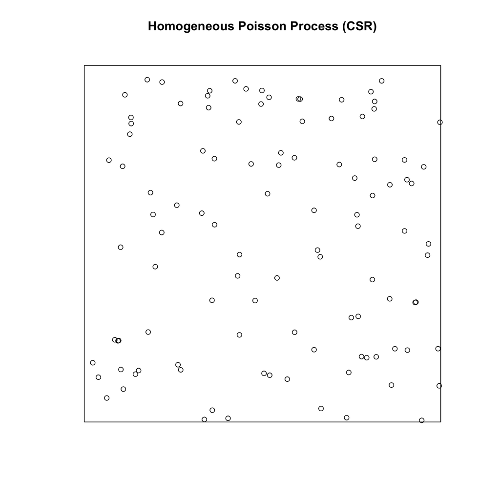

- Constant intensity
- Points are independent
- Density is a crude estimate of intensity

## Revisting CSR

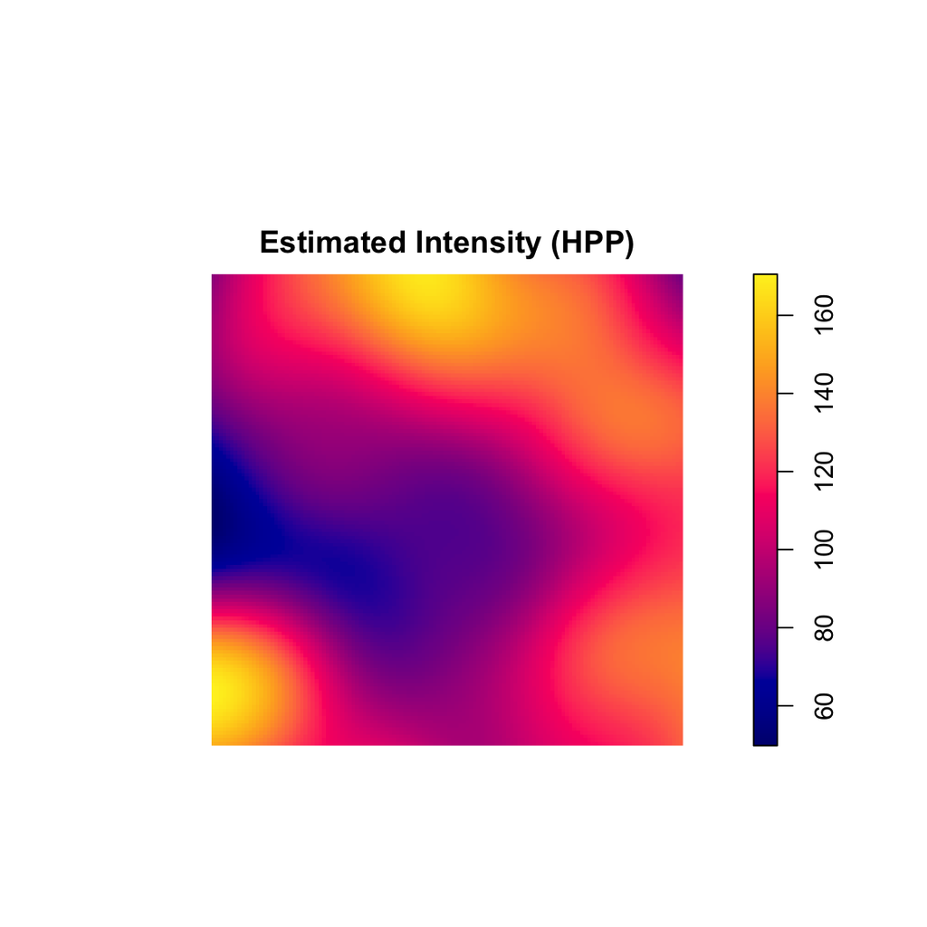

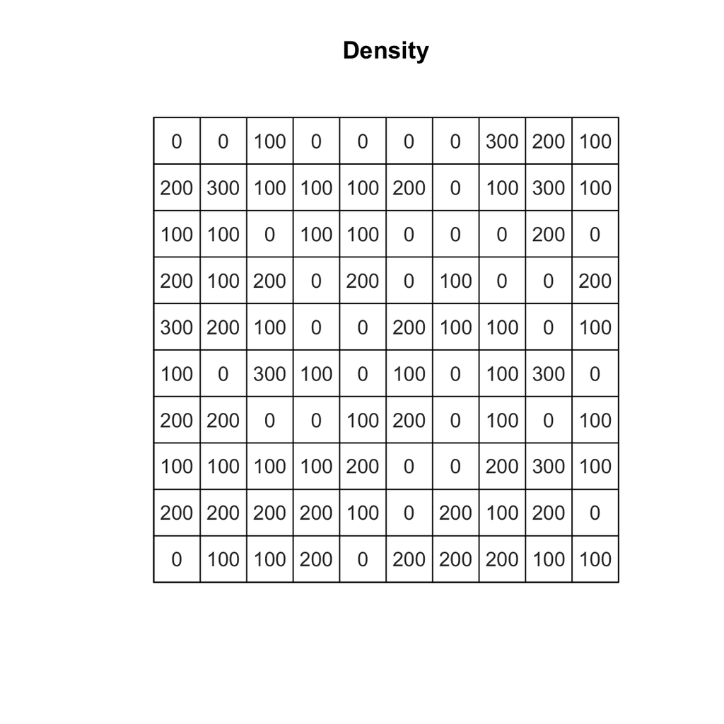

## First-Order Effects

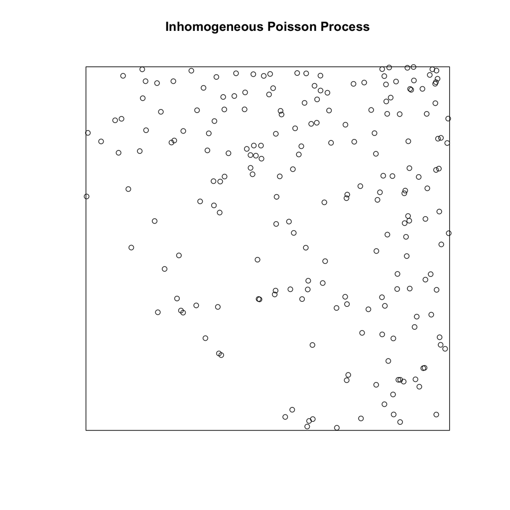

- Intensity varies spatially
- Points are independent

## First-Order Effects

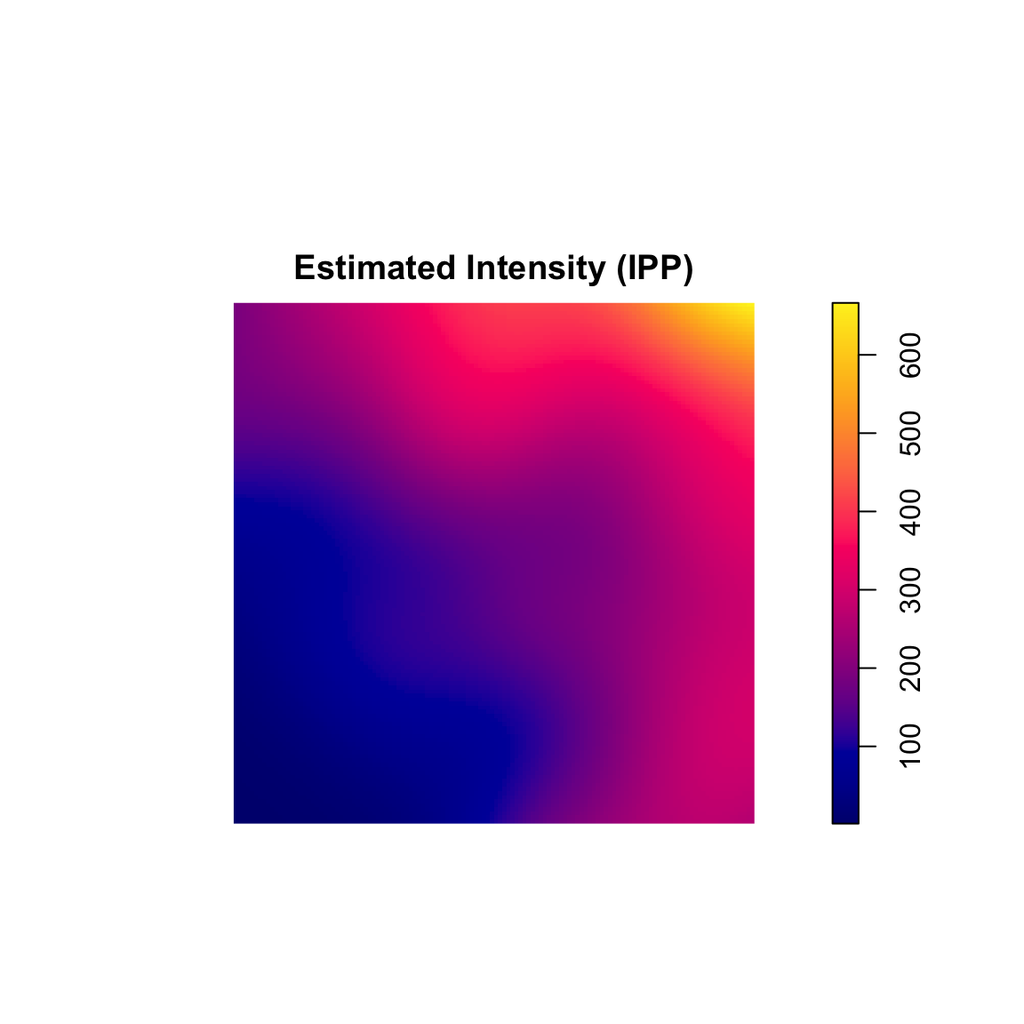

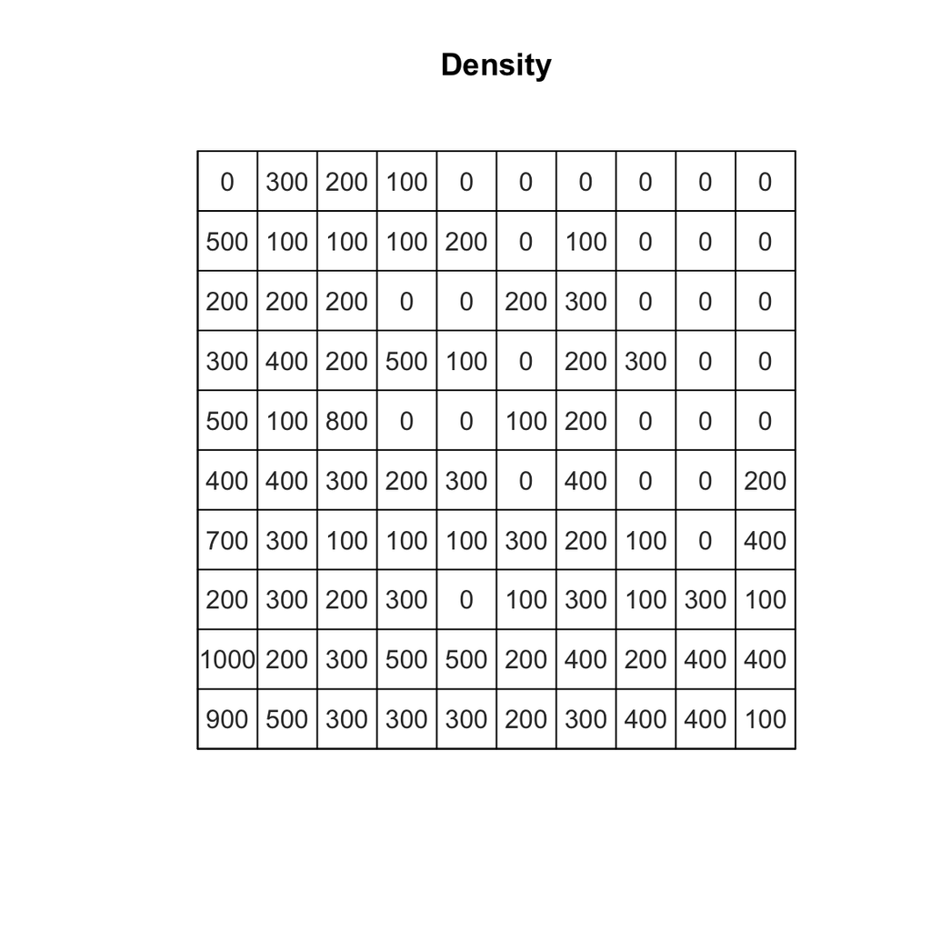

## Second-Order Effects

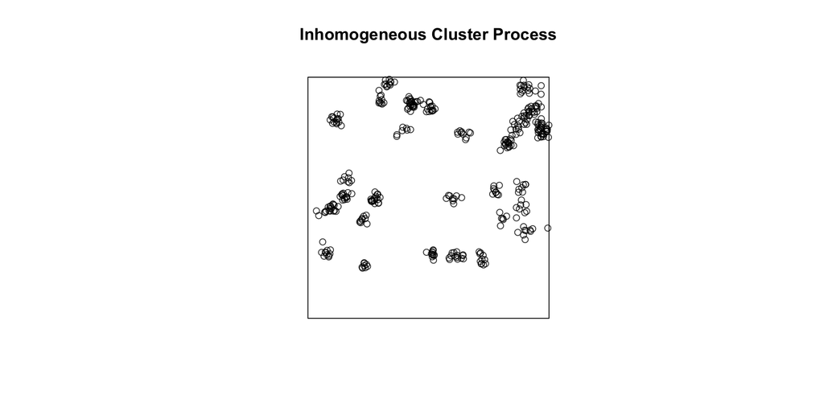

- Intensity of “parents” is first-order
- Intensity of “children” is second-order

## Second-Order Effects

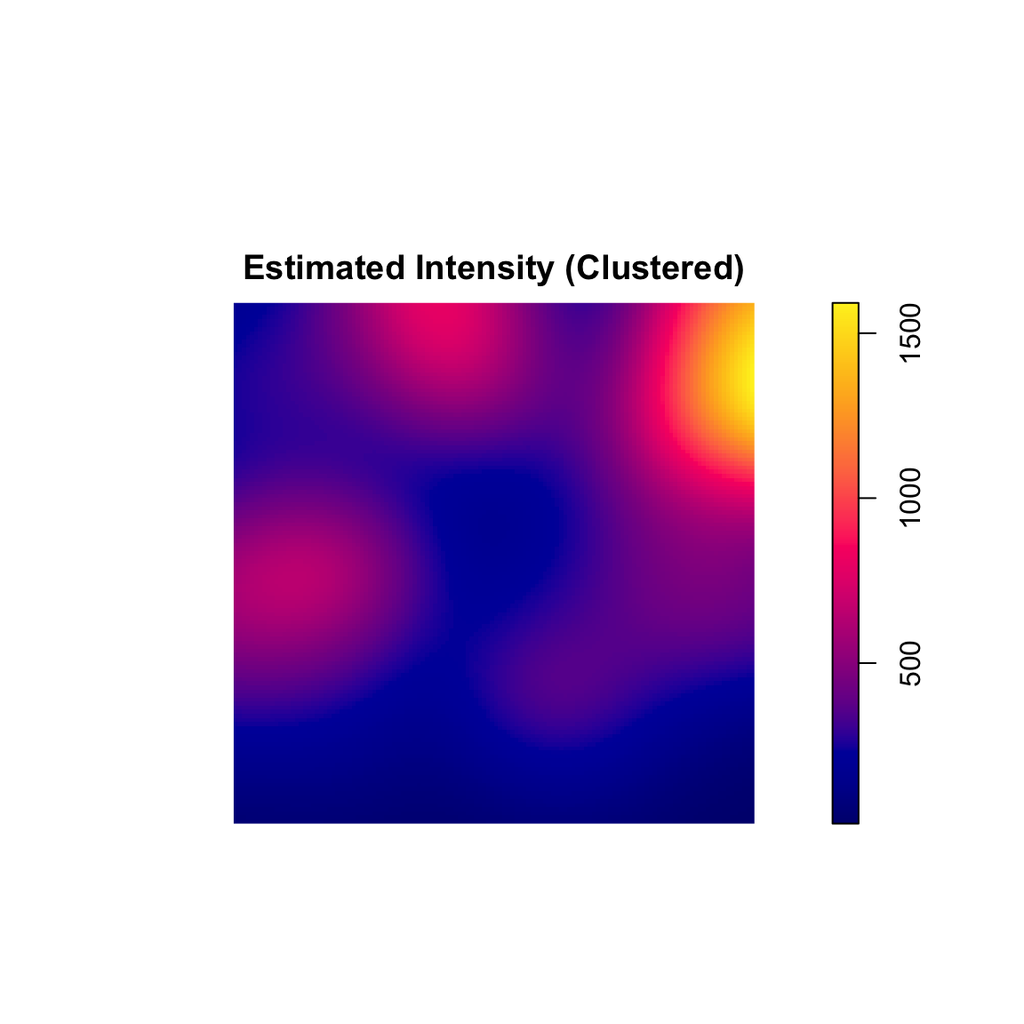

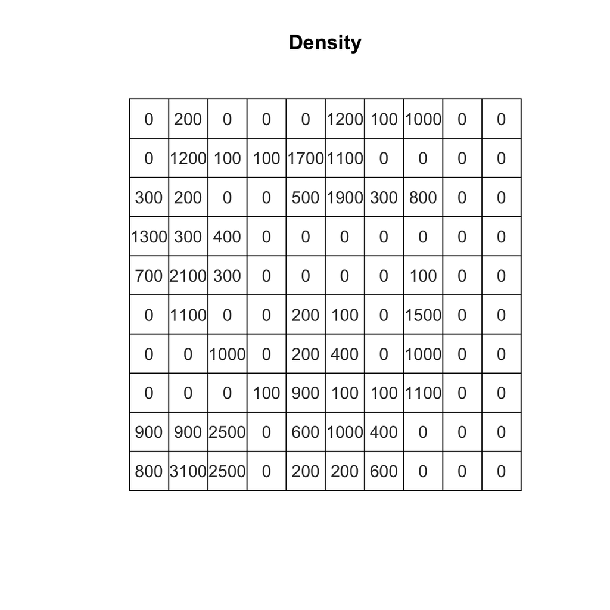

## Key Points

- Poisson distribution: mean = variance = $\lambda$ -> First Order
- **Homogeneous** refers to the rate, not it’s outcome
- Statistical tests ask “Could this outcome be generated by a constant rate?”

# Second-Order Analysis

## Distance based metrics

- Provide an estimate of the *second order* effects
- *Mean nearest-neighbor distance*:
  $$\hat{d}_{min} = \frac{\sum_{i = 1}^{m} d_{min}(\mathbf{s_i})}{n}$$

## Mean Nearest Neighbor Distance

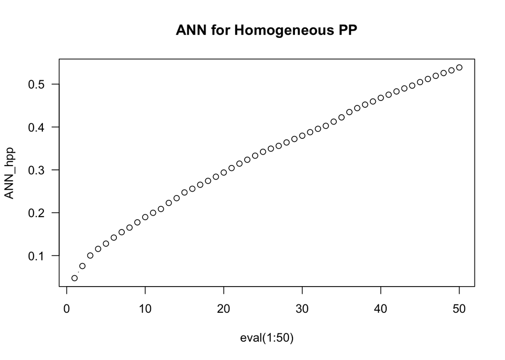

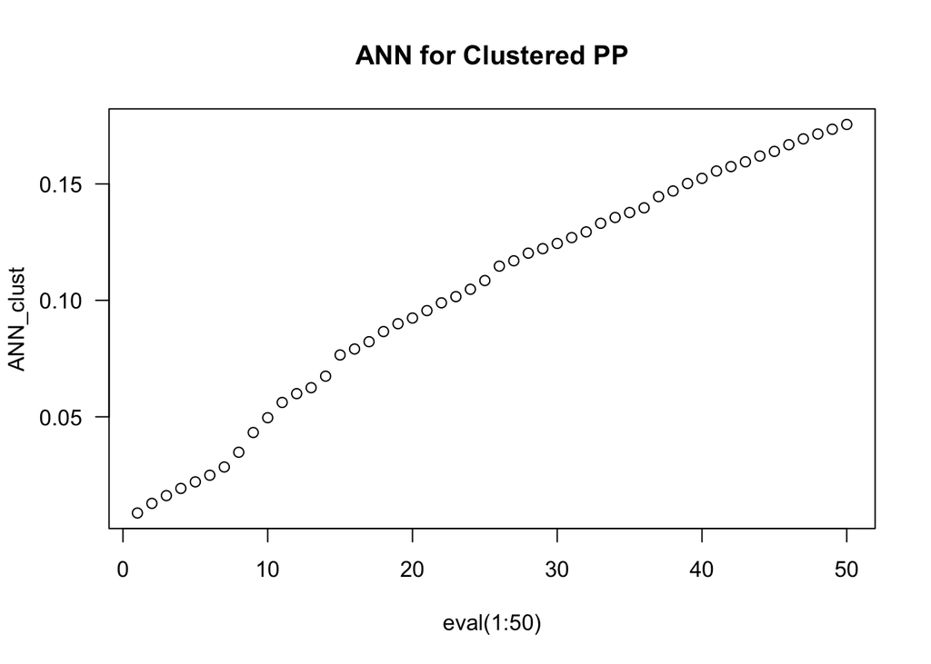

## Ripley’s $K$ Function

- Nearest neighbor methods throw away a lot of information
- The *K* function is an alternative, based on a series of circles with increasing radius

$$\begin{equation}
K(d) = \lambda^{-1}E(N_d)
\end{equation}$$

- We can test for clustering by comparing to the expectation:

$$\begin{equation}
K_{CSR}(d) = \pi d^2
\end{equation}$$

- if $k(d) > K_{CSR}(d)$ then there is clustering at the scale defined by $d$

## Ripley’s $K$ Function

- When working with a sample the distribution of $K$ is unknown
- Estimate with

$$\begin{equation}
\hat{K}(d) = \hat{\lambda}^{-1}\sum_{i=1}^n\sum_{j=1}^n\frac{I(d_{ij} <d)}{n(n-1)}
\end{equation}$$

where:

$$\begin{equation}
\hat{\lambda} = \frac{n}{|A|}
\end{equation}$$

## $K$ for HPP

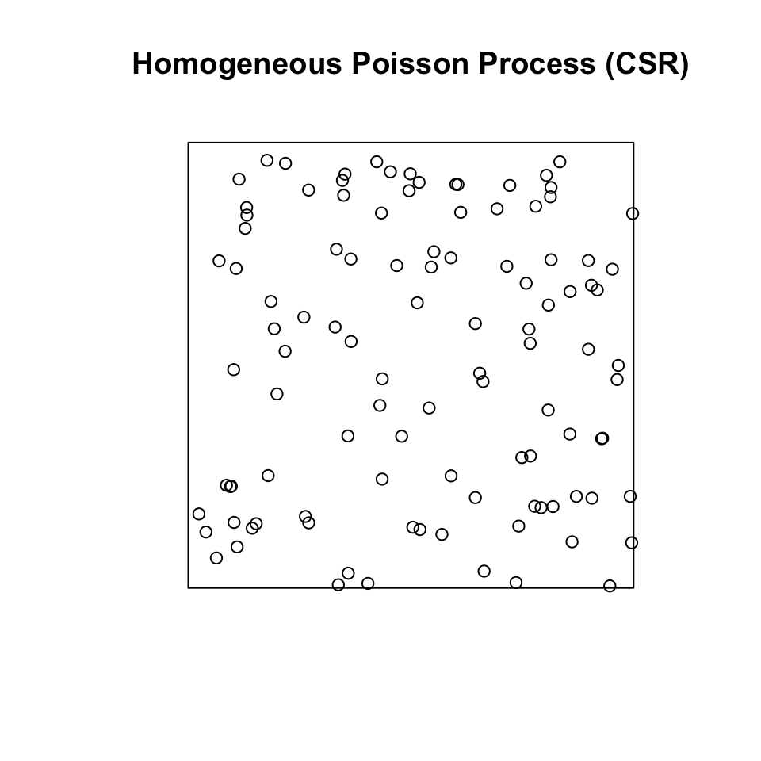

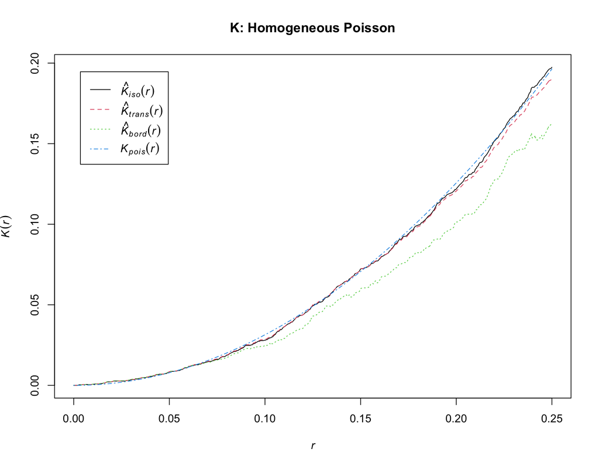

## $K$ for IPP

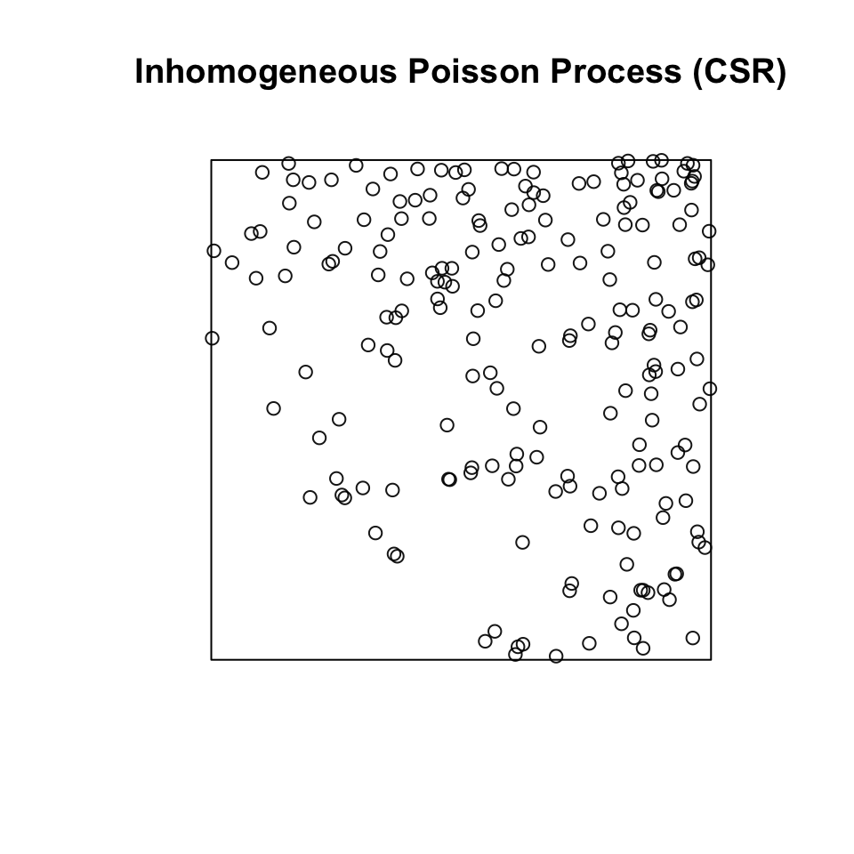

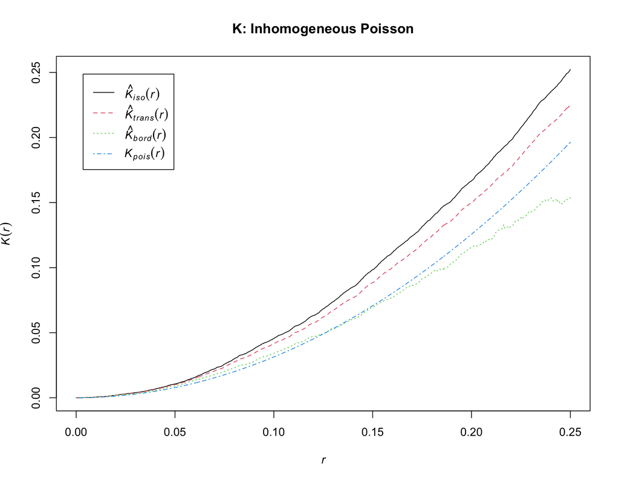

## $K$ for Clustered Processes

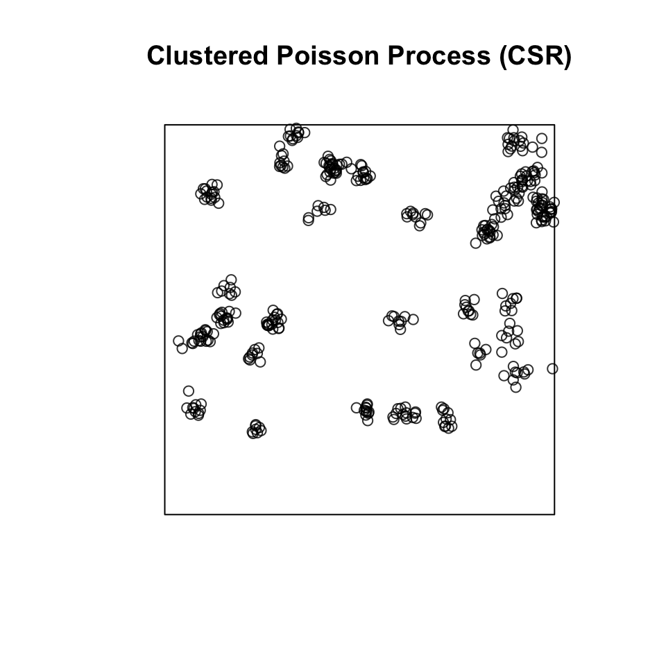

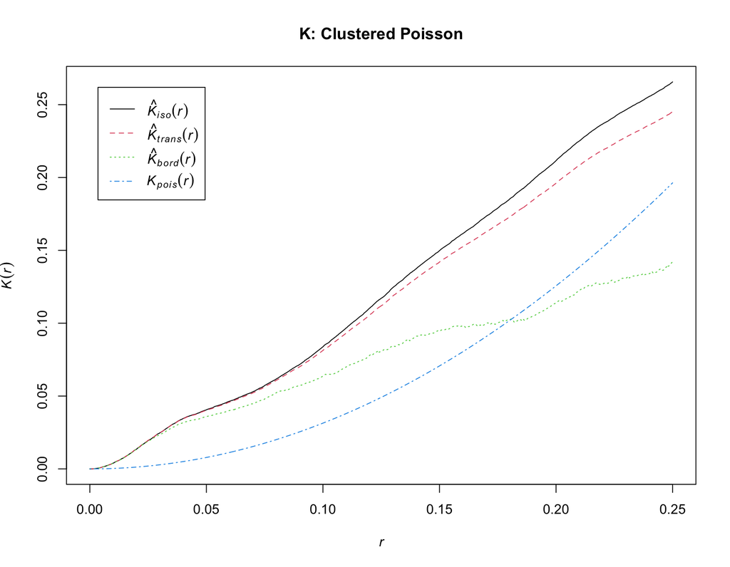

## Adjustments for $K$

- $K$ is sensitive to edge effects (window size) (`correction` argument to `Kest`)
- $K$ assumes HPP (`Kinhom` function instead of `Kest`)

## $K$ vs $Kinhom$ for IPP

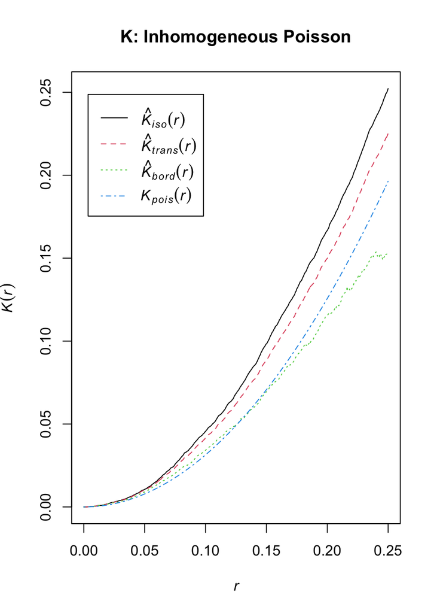

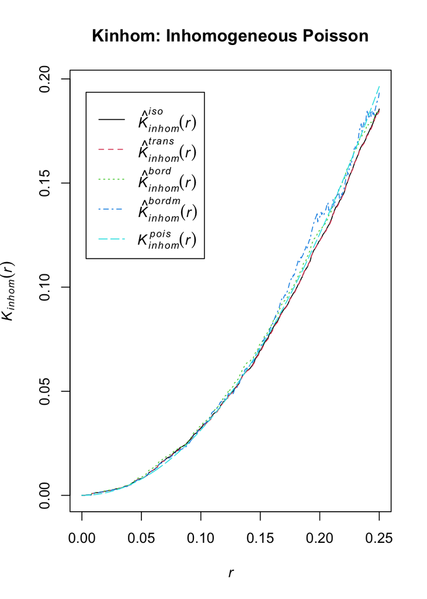

## $K$ vs $Kinhom$ for Clustered PP

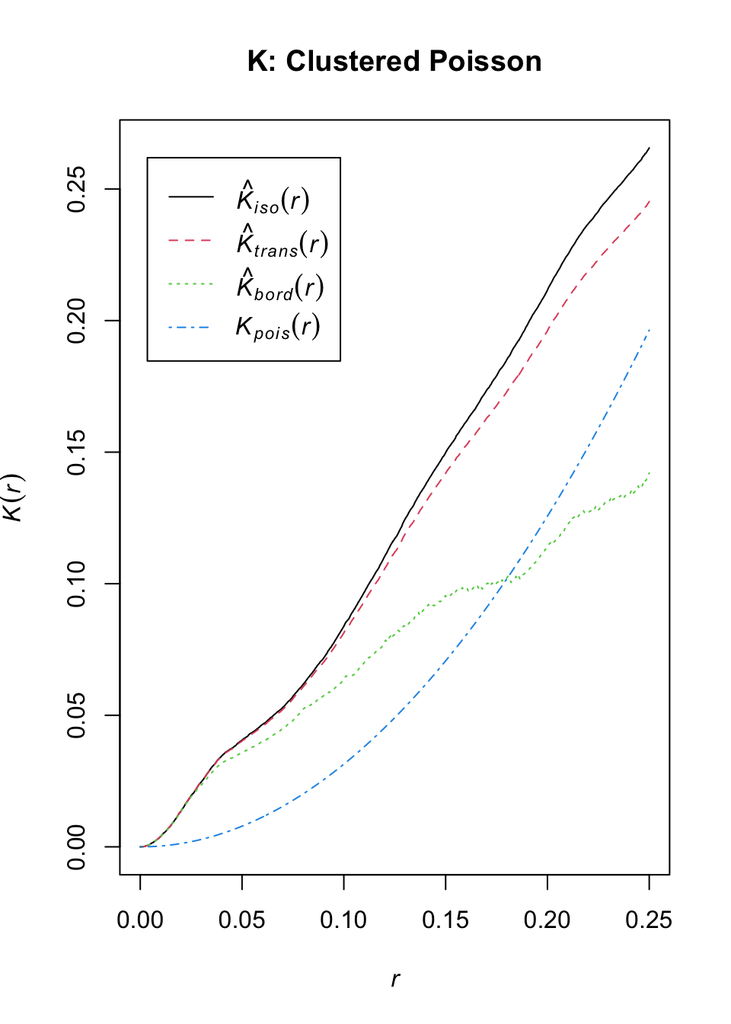

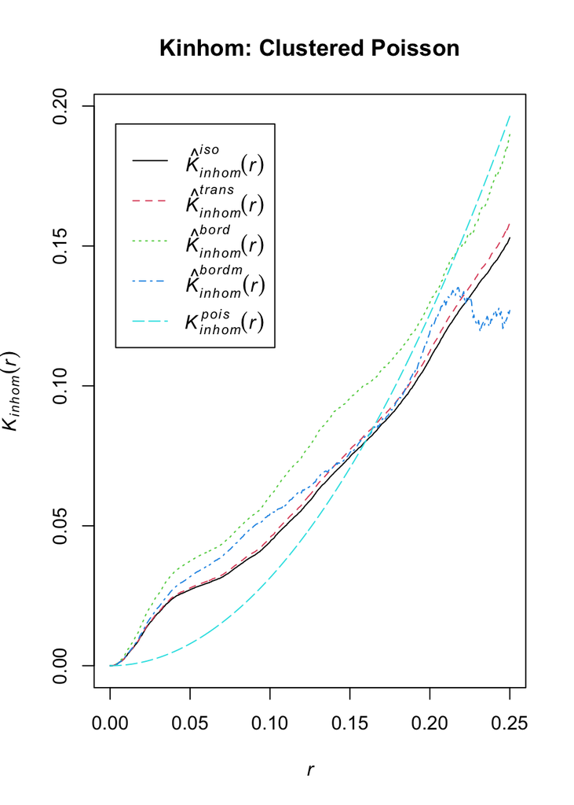

## Ripley’s $K$ Function

- accounting for variation in $d$

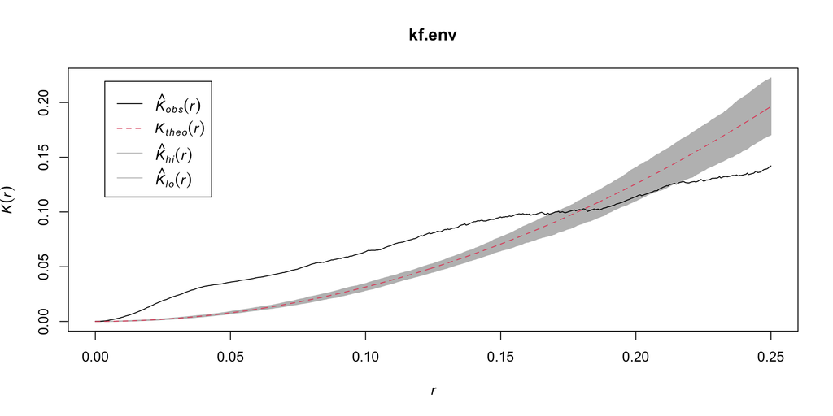

## Take-Aways

- Density and Intensity for first-order effects
- Distance for second-order effects
- Linkages for kriging and interpolation